# Assignment #2

Daniel Crownover

July 06, 2023

### Download and Read Data

```r
download.file("https://delamater.web.unc.edu/files/2019/09/WA_VACC_SCHDIST_2017.csv","vaccination_data.csv")
## download.file = downloads file/data from the internet and saves it on my computer under the name vaccination_data.csv

wavac <- read_csv("vaccination_data.csv")
## Above the previously saved file named vaccination_data.csv is now read into the R programing software with the command read_csv()
```

### Washington Data Summary

```r
## The code below is inline code.
#I input the objects to represent their corresponding numeric values.
#I used `r ...` to input the objects into their intended areas
```

The Washington school district data file has 294 rows (school districts) and 11 columns. 26 school districts reported “No Data” for enrollment and vaccination data. Statewide in 2017, there were 80523 kindergarteners, and 68995 of these kindergarteners were up to date on vaccinations, for an up to date percent of 85.68 .

### Working With a Shapefile

```r
##I know these where already pulled up in an earlier chunk but I wanted to do it again to make sure
library(sf)
library(tidyverse)

## reading in the shapefile below!
# Read in WA school district shapefile
wa.sd.sp <- st_read("wa_schdist_shapefile/WA_SCHDIST.shp")
## above we are assigning the shapefile to the object wa.sd.sp
# The R software reads this command from left to right in order to open  "wa_schdist_shapefile" --> it then opens "WA_SCHDIST.shp" inside of that folder!
wa.sd.sp  ## on this line we are providing summary info about the object!
```

```
## Simple feature collection with 294 features and 4 fields
## Geometry type: MULTIPOLYGON
## Dimension:     XY
## Bounding box:  xmin: 368970.8 ymin: 5044113 xmax: 971101.2 ymax: 5444545
## Projected CRS: NAD83 / UTM zone 10N
## First 10 features:
##      GEOID                              NAME LOGRADE HIGRADE
## 1  5307620             Royal School District      KG      12
## 2  5300780 Burlington-Edison School District      PK      12
## 3  5301680            Conway School District      KG      12
## 4  5308820            Tenino School District      KG      12
## 5  5304110         La Conner School District      KG      12
## 6  5305400      Mount Vernon School District      KG      12
## 7  5301410       Clover Park School District      PK      12
## 8  5302370        Eatonville School District      PK      12
## 9  5306690         Peninsula School District      PK      12
## 10 5308610            Sumner School District      PK      12
##                          geometry
## 1  MULTIPOLYGON (((756882.6 52...
## 2  MULTIPOLYGON (((538786.5 53...
## 3  MULTIPOLYGON (((546195.5 53...
## 4  MULTIPOLYGON (((516676.7 51...
## 5  MULTIPOLYGON (((537427.8 53...
## 6  MULTIPOLYGON (((554039.6 53...
## 7  MULTIPOLYGON (((540689.8 52...
## 8  MULTIPOLYGON (((568055.3 51...
## 9  MULTIPOLYGON (((521582.4 52...
## 10 MULTIPOLYGON (((556773.6 52...
```

```r
# Check if valid geometry
sum(st_is_valid(wa.sd.sp)) ## Equal to number of features? Not yet
```

```
## [1] 292
```

```r
# Fix geometry (easiest attempt)
wa.sd.sp <- st_make_valid(wa.sd.sp)

sum(st_is_valid(wa.sd.sp)) ## Equal to number of features? Now it is
```

```
## [1] 294
```

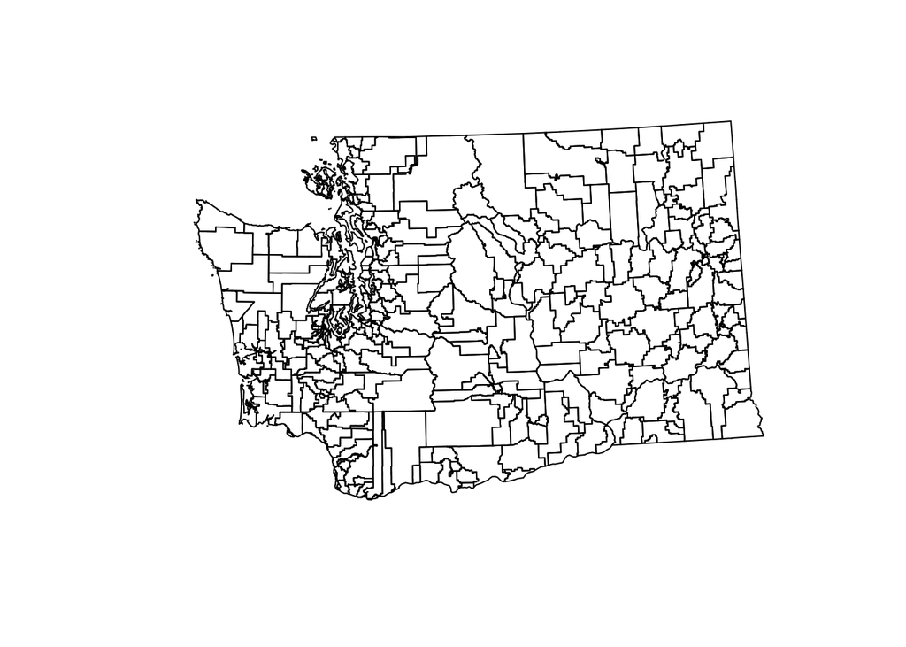

```r
## Above-these commands are indicating that there are several features with invalid geometry-- from (sum(st_is_valid(wa.sd.sp)).
## Invalid geometry often exists in data that is downloaded from the web, and means there is something with the geometry that is preventing that feature from being appropriately read by R (for instance, if the geometry self-intersects).
## Fixing the geometry using the "wa.sd.sp <- st_make_valid(wa.sd.sp)" command corrects any errors the features of the geometry have so that it can be appropriately read by R!







##  Below I am displaying the polygon features using the plot(st_geometry(wa.sd.sp)) command
## The polygon of the spacefile under the object wa.sd.sp display's in the console below.
## We use the plot command to display, the st_geometry as an argument to display geometry and the wa.sd.sp for the command to read into to derive the data.

plot(st_geometry(wa.sd.sp))
```

### QUESTION #1

How many files are associated with the Washington School Districts shapefile?

Answer: 8 files are associated with the WSD shapefile.

### QUESTION #2

Part 1.) How many observations/features are in the Washington School Districts shapefile? Answer P1: There are 294 features in the Washington School Districts shapefile

part 2.) How many columns/variables are in the Washington School Districts shapefile? Answer P2: There are 5 columns/variables in the shapefile

Work for part 1.) and part 2.) are displayed below

below I used the dimensions(dim) command to determine and print the rows(features) and columns(variables) in the tabular data set to more easily derive the answers for question 2.

RandC <- dim(wa.sd.sp) RandC

but you can also do this- there are multiple ways to get same answer:

below command displays rows R <- nrow(wa.sd.sp) R

below command displays columns C <- ncol(wa.sd.sp) C

```r
## Extract the attributes (data.frame) from an sf object
wa.sd.sp.att.data.only <- st_drop_geometry(wa.sd.sp)

## Get info
str(wa.sd.sp.att.data.only)
```

```
## 'data.frame':    294 obs. of  4 variables:
##  $ GEOID  : chr  "5307620" "5300780" "5301680" "5308820" ...
##  $ NAME   : chr  "Royal School District" "Burlington-Edison School District" "Conway School District" "Tenino School District" ...
##  $ LOGRADE: chr  "KG" "PK" "KG" "KG" ...
##  $ HIGRADE: chr  "12" "12" "12" "12" ...
```

```r
## Extract a single column of (attribute) data
sd.names <- wa.sd.sp$NAME
sd.names[1:6]
```

```
## [1] "Royal School District"             "Burlington-Edison School District"
## [3] "Conway School District"            "Tenino School District"
## [5] "La Conner School District"         "Mount Vernon School District"
```

```r
## Add a new column/variable to the sf object
wa.sd.sp$NEWCOLUMN <- 1:294

## Remove a column/variable from the sf object
wa.sd.sp$NEWCOLUMN <- NULL

## Query a column and subset
## Which school districts have PK (pre-kindergarten)?
pk.sds <- which(wa.sd.sp$LOGRADE == "PK")
length(pk.sds) # How many?
```

```
## [1] 185
```

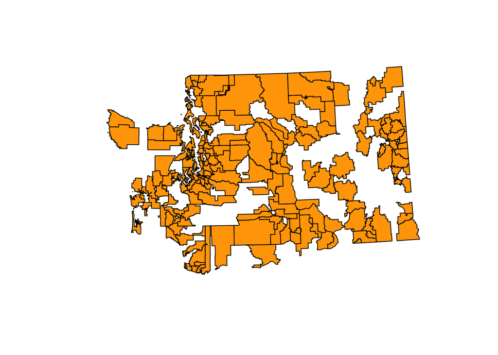

```r
## Create a new spatial data layer containing ONLY the
## school districts that have PK (subset the data)
wa.sd.sp.pk <- wa.sd.sp[pk.sds,]

## Plot the subset
plot(st_geometry(wa.sd.sp.pk), col = "orange")
```

```r
## This map shows only the districts that have PreK- highlighted in orange

## here you specifically told me not to comment for this chunk during office hours(because they already have comments)-- so I didn't explain any of the commands. Hope this is ok.
```

### Question #3

How many Washington School Districts have pre-kindergarten?

Answer: using the commands below I was able to obtain 185 districts that have PreK

Work: command below were used

pk.sds <- which(wa.sd.sp$LOGRADE == “PK”)

length(pk.sds)

### Table Join and Map

```r
##Test if a perfect match
all(wa.sd.sp$GEOID %in% wavac$GEOID)
```

```
## [1] TRUE
```

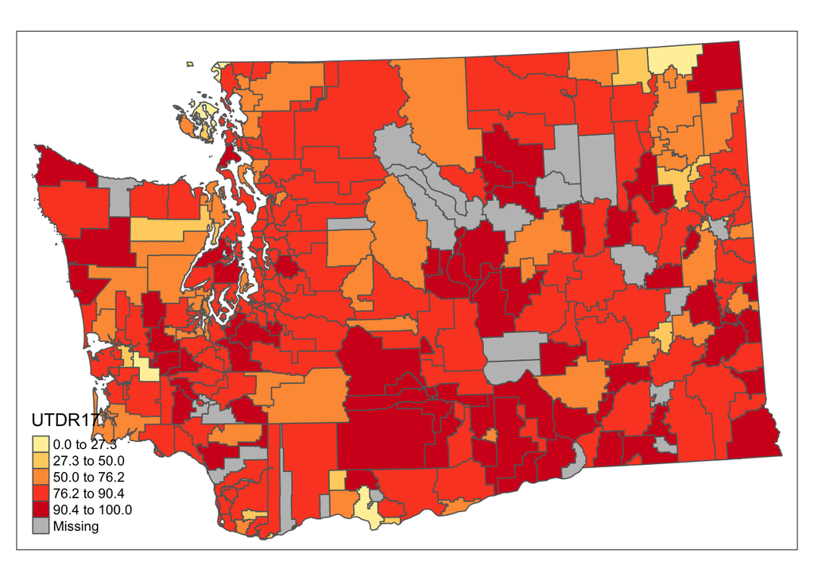

```r
## if false we could wrangle the data. But its true!

# Join vaccination data to spatial data
wa.sd.sp <- merge(wa.sd.sp,      # Spatial Data layer
                  wavac,         # Table Data layer
                  by = "GEOID")  # Key field (this is both)

## Above we are using the merge command to merge the GEOID wa.sd.sp data set with the wavac GEOID data set!


## Calculate column with Percent Up to Date
wa.sd.sp$UTDR17 <- 100 * wa.sd.sp$UTD17 / wa.sd.sp$ENR17

## Create map
## Map will display Percent of Kindergartners Up to Date on vaccination!
tm_shape(wa.sd.sp) +
  tm_polygons("UTDR17",
              style = "jenks",
              palette = "YlOrRd")
```

```r
## we are using tm_shape(wa.sd.sp) to develope the shape of the map
## we are using the tm_ polygons to develope the polygons
## the other two are color and style features
```

### QUESTION #4

What is the data type of the field GEOID in wavac? What is the data type of the field GEOID in wa.sd.sp? Where/how did you find this information?]

The data type of wa.sd.sp GEOID is: character The data type for wavac GEOID is: numeric

I derived this information from the below commands:

data type from wa.sd.sp data below:

dtype1<-class(wa.sd.sp$GEOID)

dtype1

data type from wavac data below:

dtype2<-class(wavac$GEOID)

dtype2

### QUESTION #5

Why does all(1:10 %in% 1:10) equal TRUE and all(1:5 %in% 1:10) equal TRUE, but all(1:10 %in% 1:5) equal FALSE? (2-3 sentences)?

all(1:10 %in% 1:10)

all(1:5 %in% 1:10)

all(1:10 %in% 1:5)

Answer: The reason “all(1:10 %in% 1:5)” is false is because not all of 1-10 numbers can fit inside of 1-5; in other words,all 1-10 numbers cannot fit through 1-5 because five numbers will be left out, that is why the output is false. For the other two, it is true that 1-10 numbers can fit inside 1-10 numbers and it is true that 1-5 can fit inside 1-10 without any left out. This is the best I can describe it in words- I know whats going on though, so hopefully this is sufficient.

### QUESTION #6

Do you see any interesting spatial patterns in the map of Percent of Kindergartners Up to Date on vaccination?… for example, do you see regions that are higher/lower or clumps/clusters of high/low values? (2-4 sentences)

Answer: There are several regions where the percent of kindergardners who received vaccinations in the year of 2017 is higher and in these areas they have seemed to clump together correspondingly. The red areas(or the areas containing the highest percentage of kindergarten vaccinations) border each other much of the time. The same occurs with districts that have 76.2-90.4 percent vaccinations- they cluster together. the lower the percentage of vaccinations get, the lower the cluster rate is, and th higher the dispersion rate seems to be- observationally.